# 308.2. Solar System object observations

## 5. On-sky motion rate

Plot a histogram of the on-sky motion rate and a scatter plot of the on-sky motion rate as a function of phase angle.

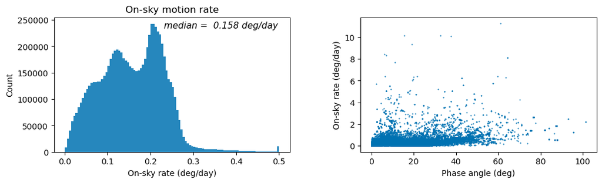

```python
fig, axes = plt.subplots(1, 2, figsize=(12, 3))

ax = axes[0]
ax.hist(results['ephRate'].clip(0, 0.5), bins=100,
        edgecolor='none', alpha=0.85)
ax.set_xlabel('On-sky rate (deg/day)')
ax.set_ylabel('Count')
ax.set_title('On-sky motion rate')
ax.text(0.95, 0.92,
        f'median = {np.median(results['ephRate']): .3f} deg/day',
        transform=ax.transAxes, ha='right', fontsize=11,
        fontstyle='italic')

ax = axes[1]
ax.scatter(results['phaseAngle'], results['ephRate'], s=0.3)
ax.set_xlabel('Phase angle (deg)')
ax.set_ylabel('On-sky rate (deg/day)')

plt.subplots_adjust(wspace=0.3)
plt.show()
```

> **Figure 5:** Histogram of on-sky motion rates with the median rate labeled (left) and scatter plot of phase angle versus on-sky motion rates (right) for all DP2 Solar System source measurements.

## 6. Phase angle and solar elongation

Plot histograms of the phase angle and solar elongation distributions.

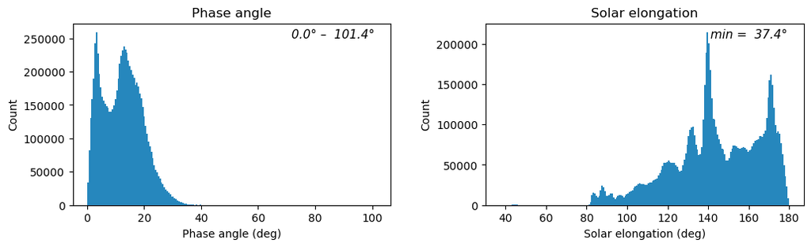

```python
fig, axes = plt.subplots(1, 2, figsize=(12, 3))

ax = axes[0]
ax.hist(results['phaseAngle'], bins=200,
        edgecolor='none', alpha=0.85)
ax.set_xlabel('Phase angle (deg)')
ax.set_ylabel('Count')
ax.set_title('Phase angle')
ax.text(0.95, 0.92,
        f'{results["phaseAngle"].min(): .1f}\u00b0 \u2013 '
        f'{results["phaseAngle"].max(): .1f}\u00b0',
        transform=ax.transAxes, ha='right', fontsize=11,
        fontstyle='italic')

ax = axes[1]
ax.hist(results['elongation'], bins=200,
        edgecolor='none', alpha=0.85)
ax.set_xlabel('Solar elongation (deg)')
ax.set_ylabel('Count')
ax.set_title('Solar elongation')
ax.text(0.95, 0.92,
        f'min = {results["elongation"].min(): .1f}\u00b0',
        transform=ax.transAxes, ha='right', fontsize=11,
        fontstyle='italic')

plt.subplots_adjust(wspace=0.3)
plt.show()
```

> **Figure 6:** Histograms of the phase angle (left) and solar elongation (right) distributions for all DP2 Solar System source measurements. The phase angle range and minimum solar elongation are labeled on each respective plot.

Plot solar elongation as a function of heliocentric distance for every Solar System source.

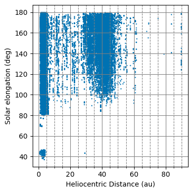

```python
fig, ax = plt.subplots(figsize=(4, 4))

ax.scatter(results['helioRange'], results['elongation'], s=0.5)
plt.xlabel('Heliocentric Distance (au)')
plt.ylabel('Solar elongation (deg)')
plt.tight_layout()
ax.xaxis.set_minor_locator(ticker.MultipleLocator(5))
ax.grid(which='major', color='gray', linestyle='-')
ax.grid(which='minor', color='gray', linestyle='--')

plt.show()
```

> **Figure 7:** Solar elongation as a function of heliocentric distance for every DP2 Solar System source. Notice a small cluster of difference image detections at low solar elongation (SE; roughly 38 - 48 deg). All but one of the low-SE detections are at a heliocentric distance < 5 au; the single low-SE outlier was observed at a heliocentric distance of nearly 30 au out near Neptune's semimajor axis. The highest concentrations in heliocentric distance (*r*) are at *r* < 5 au and roughly 30 au < *r* < 48 au (the Kuiper belt beyond Neptune); a handful of objects were detected at large heliocentric distances out to almost 90 au.

Clean up.

```python
del query, results
```